# Tarea_3_CarolinaHerrera_VictorVenegas_MonicaMagana_AndresVega_MiltonChamorro

2024-11-18

# **Caso German Credit** TEST

Un banco alemán quiere disminuir el riesgo de un tipo de crédito que ofrece a las personas. Algunos de los clientes a los cuales se les ofrece el crédito cumplen sus obligaciones de pago oportunamente mientras que otros demoran en hacer los pagos o simplemente no los hacen. Una práctica muy usual en la industria bancaria es estimar modelos estadísticos para determinar la probabilidad de pago de los clientes en función de algunas características de estos. El modelo de regresión logística es uno de los modelos más usados para esto. Los modelos determinan la probabilidad de pago de cada cliente. A los clientes con alta probabilidad de pago se les otorga el crédito mientras que a los clientes con baja probabilidad de pago se les niega la posibilidad de acceder al crédito en ese banco.

Los ejecutivos del banco seleccionan una muestra de 1000 clientes a quienes se les ha otorgado el crédito en los últimos años y se tiene información si cumplieron esta obligación con el banco o no. Adicionalmente, se dispone de las siguientes variables demográficas y de transacciones de los clientes con el banco.

1. Age (numeric)
2. Sex (text: male, female)
3. Job (numeric: 0 - unskilled and non-resident, 1 - unskilled and resident, 2 - skilled, 3 - highly skilled)
4. Housing (text: own, rent, or free)
5. Saving accounts (text - little, moderate, quite rich, rich)
6. Checking account (numeric, in DM - Deutsch Mark)
7. Credit amount (numeric, in DM)
8. Duration (numeric, in month)
9. Purpose (text: car, furniture/equipment, radio/TV, domestic appliances, repairs, education, business, vacation/others)

```r
# Carga de datos

# Andres
# datos <- read.csv(file = 'german_credit_data.csv',header = T)
# datos <- df_datos[1:11]

# Víctor
# ruta = '/Users/victorvenegaspezo/Documents/Magister Business Analytics/Modelos Analiticos/Modulo 3 Regresion Logistica/Tarea/german_credit_data.csv'

# Mónica
datos <- read.csv(file = 'german_credit_data.csv',header = T)
datos <- datos %>%
  drop_na()
colnames(datos)
```

```
##  [1] "Id"               "Age"              "Sex"              "Job"
##  [5] "Housing"          "Saving.accounts"  "Checking.account" "Credit.amount"
##  [9] "Duration"         "Purpose"          "Good"
```

```r
dim(datos)
```

```
## [1] 522  11
```

```r
head(datos)
```

|  | Id | Age | Sex | Job | Housing | Saving.accounts | Checking.account | Credit.amount | Duration | Purpose | Good |
| --- | --- | --- | --- | --- | --- | --- | --- | --- | --- | --- | --- |
| 1 | 1 | 22 | female | 2 | own | little | moderate | 5951 | 48 | radio/TV | 0 |
| 2 | 3 | 45 | male | 2 | free | little | little | 7882 | 42 | furniture/equipment | 1 |
| 3 | 4 | 53 | male | 2 | free | little | little | 4870 | 24 | car | 0 |
| 4 | 7 | 35 | male | 3 | rent | little | moderate | 6948 | 36 | car | 1 |
| 5 | 9 | 28 | male | 3 | own | little | moderate | 5234 | 30 | car | 0 |
| 6 | 10 | 25 | female | 2 | rent | little | moderate | 1295 | 12 | car | 0 |

```r
summary(datos)
```

```
##        Id             Age            Sex                 Job
##  Min.   :  1.0   Min.   :19.00   Length:522         Min.   :0.000
##  1st Qu.:233.5   1st Qu.:26.00   Class :character   1st Qu.:2.000
##  Median :502.5   Median :31.50   Mode  :character   Median :2.000
##  Mean   :493.5   Mean   :34.89                      Mean   :1.875
##  3rd Qu.:736.8   3rd Qu.:41.00                      3rd Qu.:2.000
##  Max.   :999.0   Max.   :75.00                      Max.   :3.000
##    Housing          Saving.accounts    Checking.account   Credit.amount
##  Length:522         Length:522         Length:522         Min.   :  276
##  Class :character   Class :character   Class :character   1st Qu.: 1298
##  Mode  :character   Mode  :character   Mode  :character   Median : 2326
##                                                           Mean   : 3279
##                                                           3rd Qu.: 3971
##                                                           Max.   :18424
##     Duration       Purpose               Good
##  Min.   : 6.00   Length:522         Min.   :0.0000
##  1st Qu.:12.00   Class :character   1st Qu.:0.0000
##  Median :18.00   Mode  :character   Median :1.0000
##  Mean   :21.34                      Mean   :0.5575
##  3rd Qu.:26.75                      3rd Qu.:1.0000
##  Max.   :72.00                      Max.   :1.0000
```

```r
# Limpieza de datos
datos <- datos %>%
  mutate(Job = factor(Job,
                      levels = c(0, 1, 2, 3),
                      labels = c("unskilled and non-resident",
                                 "unskilled and resident",
                                 "skilled",
                                 "highly skilled")),
         Sex = factor(Sex),
         Housing = factor(Housing),
         Saving.accounts = factor(Saving.accounts),
         Checking.account = factor(Checking.account),
         Purpose = factor(Purpose),
         Good = factor(Good,
                       levels = c(0, 1),
                       labels = c("Not Good", "Good"))
         )
```

## Sección A

Calcule estadísticas descriptivas de los datos y en base a estas determine potenciales observaciones inusuales.

```r
skimr::skim(datos)
```

Data summary

| Name | datos |
| --- | --- |
| Number of rows | 522 |
| Number of columns | 11 |
| _______________________ |  |
| Column type frequency: |  |
| factor | 7 |
| numeric | 4 |
| ________________________ |  |
| Group variables | None |

**Variable type: factor**

| skim_variable | n_missing | complete_rate | ordered | n_unique | top_counts |
| --- | --- | --- | --- | --- | --- |
| Sex | 0 | 1 | FALSE | 2 | mal: 354, fem: 168 |
| Job | 0 | 1 | FALSE | 4 | ski: 313, uns: 116, hig: 79, uns: 14 |
| Housing | 0 | 1 | FALSE | 3 | own: 349, ren: 108, fre: 65 |
| Saving.accounts | 0 | 1 | FALSE | 4 | lit: 412, mod: 64, qui: 23, ric: 23 |
| Checking.account | 0 | 1 | FALSE | 3 | lit: 245, mod: 224, ric: 53 |
| Purpose | 0 | 1 | FALSE | 8 | car: 173, rad: 132, fur: 107, bus: 53 |
| Good | 0 | 1 | FALSE | 2 | Goo: 291, Not: 231 |

**Variable type: numeric**

| skim_variable | n_missing | complete_rate | mean | sd | p0 | p25 | p50 | p75 | p100 | hist |
| --- | --- | --- | --- | --- | --- | --- | --- | --- | --- | --- |
| Id | 0 | 1 | 493.52 | 291.13 | 1 | 233.5 | 502.5 | 736.75 | 999 | ▇▇▇▇▇ |
| Age | 0 | 1 | 34.89 | 11.79 | 19 | 26.0 | 31.5 | 41.00 | 75 | ▇▅▂▁▁ |
| Credit.amount | 0 | 1 | 3278.75 | 2929.16 | 276 | 1297.5 | 2326.5 | 3971.25 | 18424 | ▇▂▁▁▁ |
| Duration | 0 | 1 | 21.34 | 12.47 | 6 | 12.0 | 18.0 | 26.75 | 72 | ▇▃▂▁▁ |

```r
# Convertir el conjunto de datos para visualización
melted_data <- melt(data = datos %>% select(-Id), factorsAsStrings = T)
```

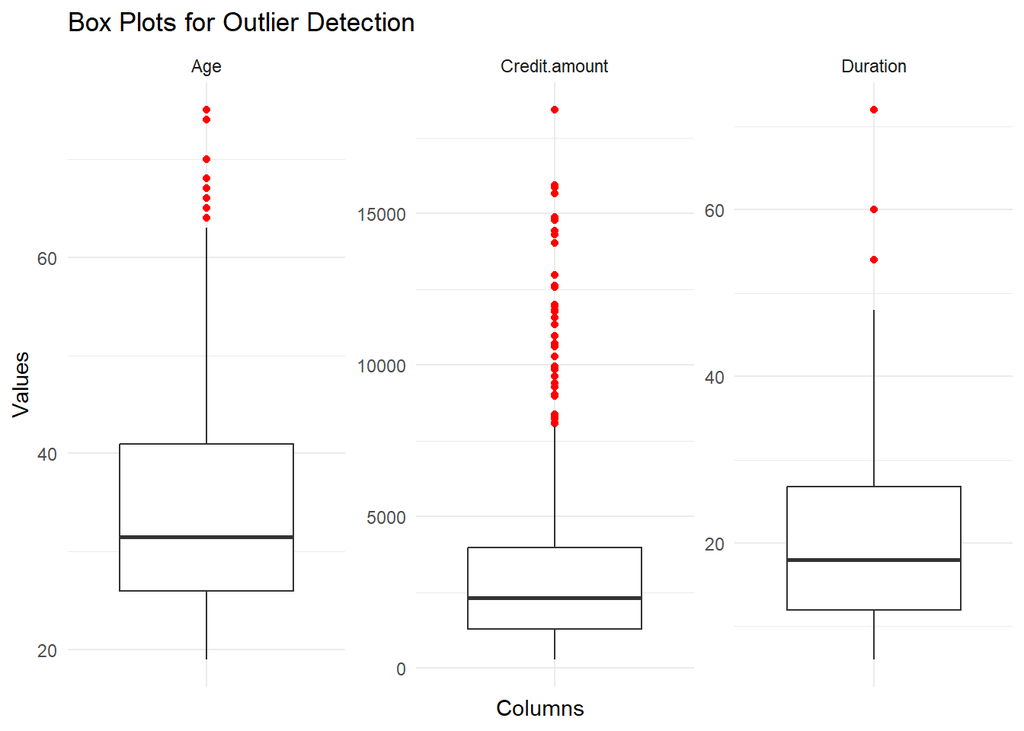

```r
# Boxplot para todas las variables numéricas
ggplot(melted_data, aes(x = "", y = value)) +
  geom_boxplot(outlier.colour = "red", outlier.shape = 16) +
  facet_wrap(~ variable, scales = "free") +
  theme_minimal() +
  labs(title = "Box Plots for Outlier Detection",
       x = "Columns",
       y = "Values") +
  theme(axis.text.x = element_blank(),
        axis.ticks.x = element_blank())
```

```r
# Detección de outliers usando el método IQR
find_outliers <- function(column) {
  Q1 <- quantile(column, 0.25, na.rm = TRUE)
  Q3 <- quantile(column, 0.75, na.rm = TRUE)
  IQR <- Q3 - Q1
  lower_limit <- Q1 - 1.5 * IQR
  upper_limit <- Q3 + 1.5 * IQR
  outliers <- column[column < lower_limit | column > upper_limit]

  #print(paste0('Límite inferior: ', lower_limit, ' Límite superior: ', upper_limit))
  return(outliers)
}


# Capturar outliers para todas las columnas numéricas
outliers_list <- lapply(datos, function(col) {
  if (is.numeric(col)) {
    return(find_outliers(col))
  } else {
    return(NULL)
  }
})


# Crear un data frame con los outliers encontrados
outliers_dataset <- data.frame(
  Column = names(outliers_list),
  Outliers = sapply(outliers_list, function(x) paste(x, collapse = ", "))
)

# Filtrar y mostrar solo las columnas con outliers
outliers_dataset <- outliers_dataset[outliers_dataset$Outliers != "", ]
print(outliers_dataset)
```

```
##                      Column
## Age                     Age
## Credit.amount Credit.amount
## Duration           Duration
##                                                                                                                                                                                                                                                   Outliers
## Age                                                                                                                                                                                 66, 66, 70, 65, 74, 68, 66, 75, 65, 67, 65, 64, 66, 74, 66, 67, 68, 64
## Credit.amount 12579, 14421, 12612, 15945, 11938, 10623, 10961, 8978, 11998, 10722, 9398, 9960, 14782, 14318, 12976, 11760, 11328, 8318, 9034, 8086, 9857, 14027, 11560, 8065, 9271, 9283, 9629, 15857, 11816, 15672, 18424, 14896, 10297, 8358, 8386, 8229
## Duration                                                                                                                                                                                                                    60, 54, 60, 60, 72, 60, 60, 60
```

```r
# Cantidad de outliers para cada variable
print(paste('Cantidad de outliers para Age: ', length(outliers_list$Age)))
```

```
## [1] "Cantidad de outliers para Age:  18"
```

```r
print(paste('Cantidad de outliers para Credit.amount: ', length(outliers_list$Credit.amount)))
```

```
## [1] "Cantidad de outliers para Credit.amount:  36"
```

```r
print(paste('Cantidad de outliers para Duration: ', length(outliers_list$Duration)))
```

```
## [1] "Cantidad de outliers para Duration:  8"
```

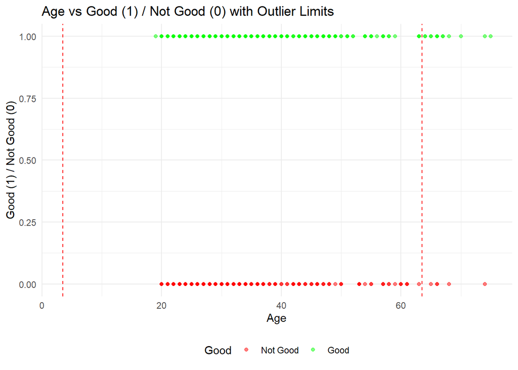

```r
### Gráficos de dispersion
# Calcular los límites IQR para Age, Credit.amount y Duration
age_limits <- quantile(datos$Age, c(0.25, 0.75), na.rm = TRUE)
credit_amount_limits <- quantile(datos$Credit.amount, c(0.25, 0.75), na.rm = TRUE)
duration_limits <- quantile(datos$Duration, c(0.25, 0.75), na.rm = TRUE)

IQR_age <- age_limits[2] - age_limits[1]
IQR_credit_amount <- credit_amount_limits[2] - credit_amount_limits[1]
IQR_duration <- duration_limits[2] - duration_limits[1]

# Calcular los límites de los outliers
age_lower <- age_limits[1] - 1.5 * IQR_age
age_upper <- age_limits[2] + 1.5 * IQR_age

credit_amount_lower <- credit_amount_limits[1] - 1.5 * IQR_credit_amount
credit_amount_upper <- credit_amount_limits[2] + 1.5 * IQR_credit_amount

duration_lower <- duration_limits[1] - 1.5 * IQR_duration
duration_upper <- duration_limits[2] + 1.5 * IQR_duration


ggplot(datos, aes(x = Age, y = as.numeric(Good) - 1, color = Good)) +
  geom_point(alpha = 0.5) +
  geom_vline(xintercept = age_lower, color = "red", linetype = "dashed") +  # Línea para límite inferior
  geom_vline(xintercept = age_upper, color = "red", linetype = "dashed") +  # Línea para límite superior
  labs(title = "Age vs Good (1) / Not Good (0) with Outlier Limits",
       x = "Age",
       y = "Good (1) / Not Good (0)") +
  scale_color_manual(values = c("red", "green")) +
  theme_minimal() +
  theme(legend.position = "bottom")
```

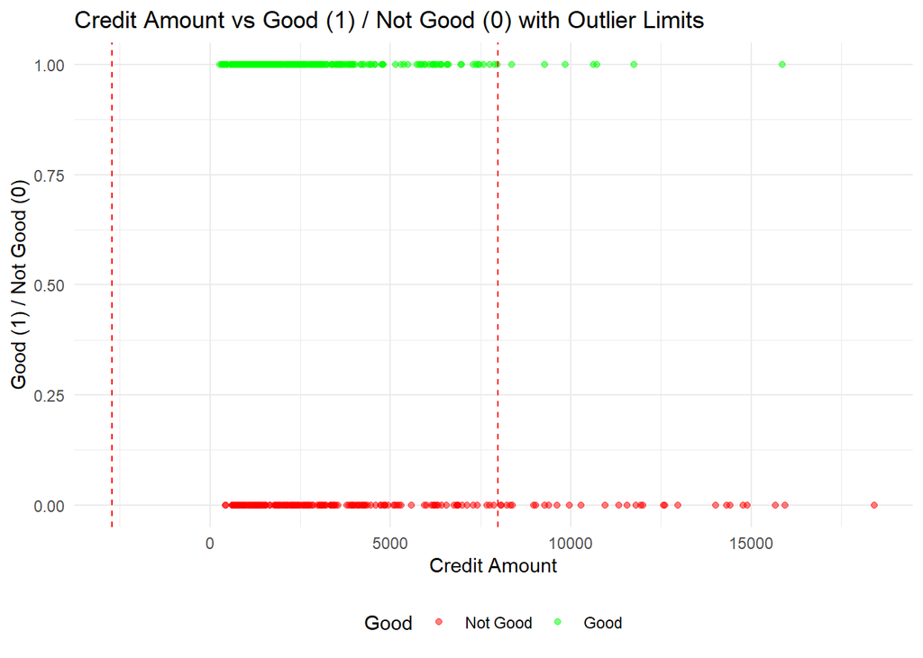

```r
ggplot(datos, aes(x = Credit.amount, y = as.numeric(Good) - 1, color = Good)) +
  geom_point(alpha = 0.5) +
  geom_vline(xintercept = credit_amount_lower, color = "red", linetype = "dashed") +  # Línea para límite inferior
  geom_vline(xintercept = credit_amount_upper, color = "red", linetype = "dashed") +  # Línea para límite superior
  labs(title = "Credit Amount vs Good (1) / Not Good (0) with Outlier Limits",
       x = "Credit Amount",
       y = "Good (1) / Not Good (0)") +
  scale_color_manual(values = c("red", "green")) +
  theme_minimal() +
  theme(legend.position = "bottom")
```

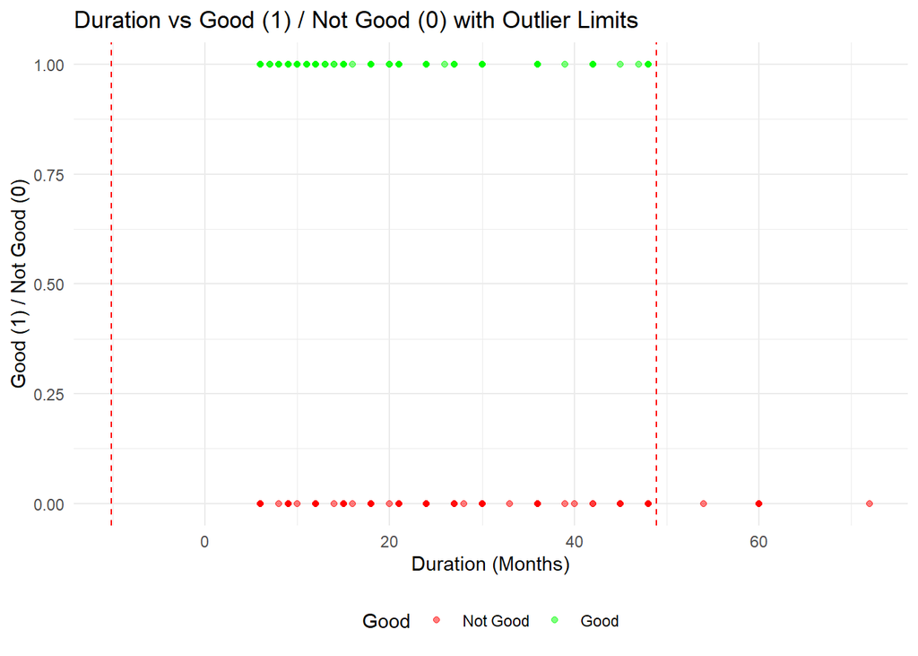

```r
ggplot(datos, aes(x = Duration, y = as.numeric(Good) - 1, color = Good)) +
  geom_point(alpha = 0.5) +
  geom_vline(xintercept = duration_lower, color = "red", linetype = "dashed") +  # Línea para límite inferior
  geom_vline(xintercept = duration_upper, color = "red", linetype = "dashed") +  # Línea para límite superior
  labs(title = "Duration vs Good (1) / Not Good (0) with Outlier Limits",
       x = "Duration (Months)",
       y = "Good (1) / Not Good (0)") +
  scale_color_manual(values = c("red", "green")) +
  theme_minimal() +
  theme(legend.position = "bottom")
```

```r
### Analisis de correlación
# 1. Cálculo de la matriz de correlación entre las variables numéricas

# Seleccionar las variables numéricas
numeric_vars <- datos %>% select(Age, Credit.amount, Duration)

# Calcular la matriz de correlación
correlation_matrix <- cor(numeric_vars, use = "complete.obs")  # usa complete.obs para ignorar NA

# Ver la matriz de correlación
print("Matriz de Correlación entre variables numéricas:")
```

```
## [1] "Matriz de Correlación entre variables numéricas:"
```

```r
print(correlation_matrix)
```

```
##                       Age Credit.amount    Duration
## Age           1.000000000    0.08201393 0.001548979
## Credit.amount 0.082013934    1.00000000 0.613297863
## Duration      0.001548979    0.61329786 1.000000000
```

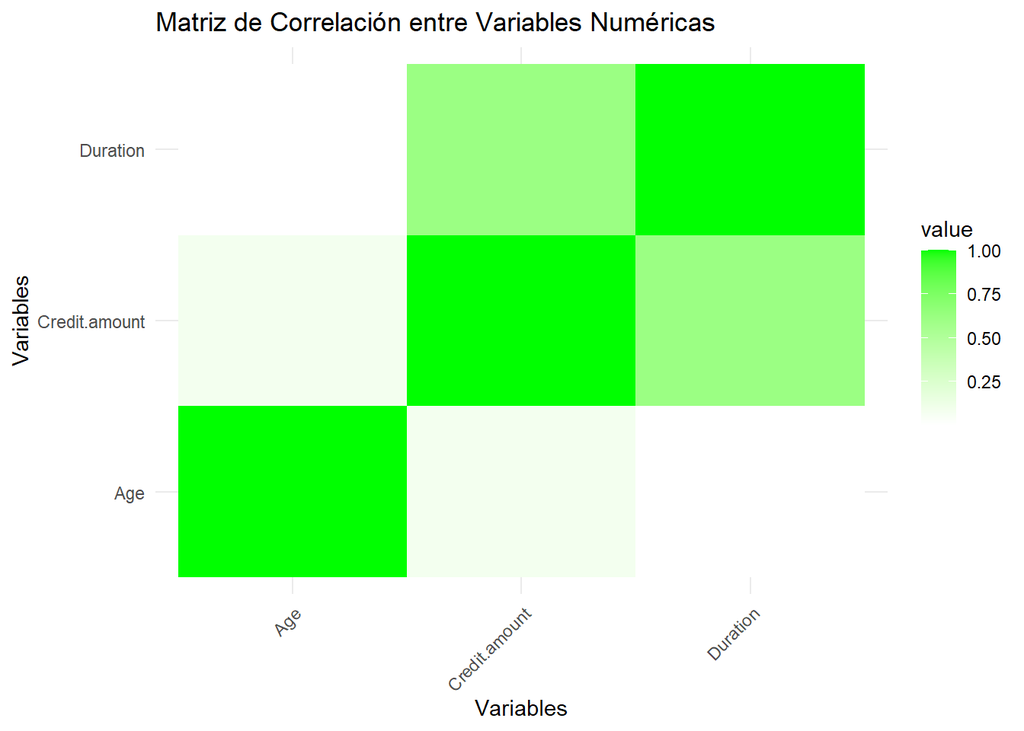

```r
# 2. Visualización de la correlación con un mapa de calor (heatmap)
# Convertir la matriz de correlación en formato largo para ggplot
correlation_melted <- melt(correlation_matrix)

# Visualizar la matriz de correlación usando ggplot2 (mapa de calor)
ggplot(correlation_melted, aes(Var1, Var2, fill = value)) +
  geom_tile() +
  scale_fill_gradient2(low = "red", high = "green", mid = "white", midpoint = 0) +
  theme_minimal() +
  labs(title = "Matriz de Correlación entre Variables Numéricas",
       x = "Variables", y = "Variables") +
  theme(axis.text.x = element_text(angle = 45, hjust = 1)) # Rotar etiquetas del eje X
```

```r
# 3. Análisis de la relación entre variables categóricas y la variable dependiente `Good`

# Para cada variable categórica, se realiza la prueba de chi-cuadrado
categorical_vars <- c("Sex", "Job", "Housing", "Saving.accounts", "Checking.account", "Purpose")

# Recorremos las variables categóricas y realizamos la prueba de chi-cuadrado
for (var in categorical_vars) {
  cat("\nPrueba Chi-Cuadrado para la variable", var, "y Good:\n")
  chisq_test <- chisq.test(table(datos[[var]], datos$Good))
  print(chisq_test)
}
```

```
##
## Prueba Chi-Cuadrado para la variable Sex y Good:
##
##  Pearson's Chi-squared test with Yates' continuity correction
##
## data:  table(datos[[var]], datos$Good)
## X-squared = 1.8215, df = 1, p-value = 0.1771
##
##
## Prueba Chi-Cuadrado para la variable Job y Good:
##
##  Pearson's Chi-squared test
##
## data:  table(datos[[var]], datos$Good)
## X-squared = 1.8872, df = 3, p-value = 0.5961
##
##
## Prueba Chi-Cuadrado para la variable Housing y Good:
##
##  Pearson's Chi-squared test
##
## data:  table(datos[[var]], datos$Good)
## X-squared = 8.5627, df = 2, p-value = 0.01382
##
##
## Prueba Chi-Cuadrado para la variable Saving.accounts y Good:
##
##  Pearson's Chi-squared test
##
## data:  table(datos[[var]], datos$Good)
## X-squared = 10.723, df = 3, p-value = 0.01332
##
##
## Prueba Chi-Cuadrado para la variable Checking.account y Good:
##
##  Pearson's Chi-squared test
##
## data:  table(datos[[var]], datos$Good)
## X-squared = 12.676, df = 2, p-value = 0.001768
##
##
## Prueba Chi-Cuadrado para la variable Purpose y Good:
```

```
##
##  Pearson's Chi-squared test
##
## data:  table(datos[[var]], datos$Good)
## X-squared = 6.8441, df = 7, p-value = 0.4453
```

```r
# 4. Análisis de la relación entre variables numéricas y la variable dependiente `Good`

# Calcular la correlación de Pearson entre las variables numéricas y la variable 'Good'
# Convertir 'Good' a numérica (0 = Not Good, 1 = Good)
cor_age_good <- cor(datos$Age, as.numeric(datos$Good), use = "complete.obs")
cor_credit_amount_good <- cor(datos$Credit.amount, as.numeric(datos$Good), use = "complete.obs")
cor_duration_good <- cor(datos$Duration, as.numeric(datos$Good), use = "complete.obs")

# Imprimir las correlaciones
cat("\nCorrelación entre Age y Good:", cor_age_good, "\n")
```

```
##
## Correlación entre Age y Good: 0.05611367
```

```r
cat("Correlación entre Credit.amount y Good:", cor_credit_amount_good, "\n")
```

```
## Correlación entre Credit.amount y Good: -0.1833915
```

```r
cat("Correlación entre Duration y Good:", cor_duration_good, "\n")
```

```
## Correlación entre Duration y Good: -0.2936106
```

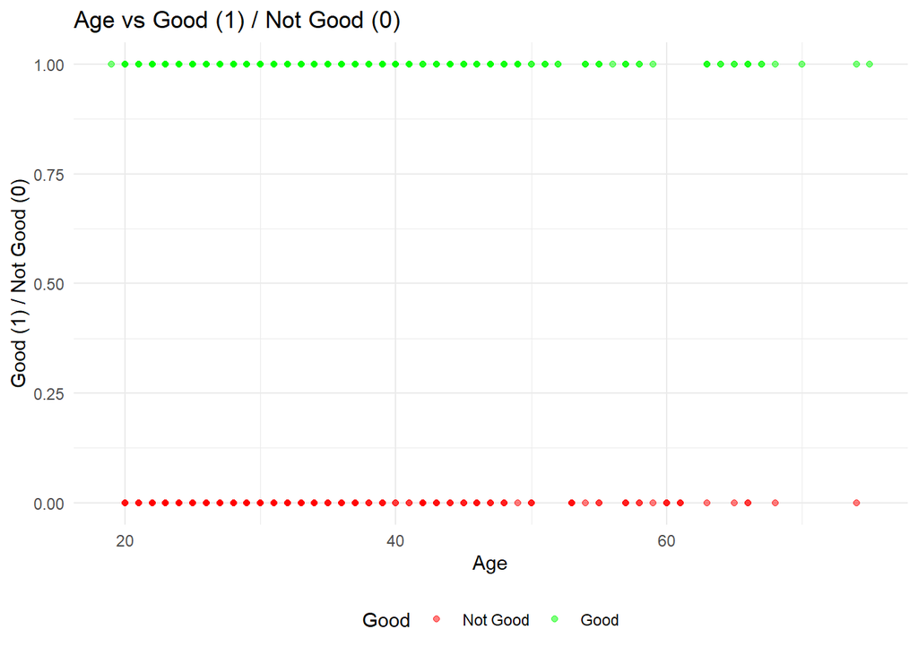

```r
# 5. Visualización de la relación entre variables numéricas y Good

# Gráficos de dispersión con la variable dependiente 'Good' para las variables numéricas

# Gráfico de dispersión para Age vs Good
ggplot(datos, aes(x = Age, y = as.numeric(Good) - 1, color = Good)) +
  geom_point(alpha = 0.5) +
  labs(title = "Age vs Good (1) / Not Good (0)", x = "Age", y = "Good (1) / Not Good (0)") +
  scale_color_manual(values = c("red", "green")) +
  theme_minimal() +
  theme(legend.position = "bottom")
```

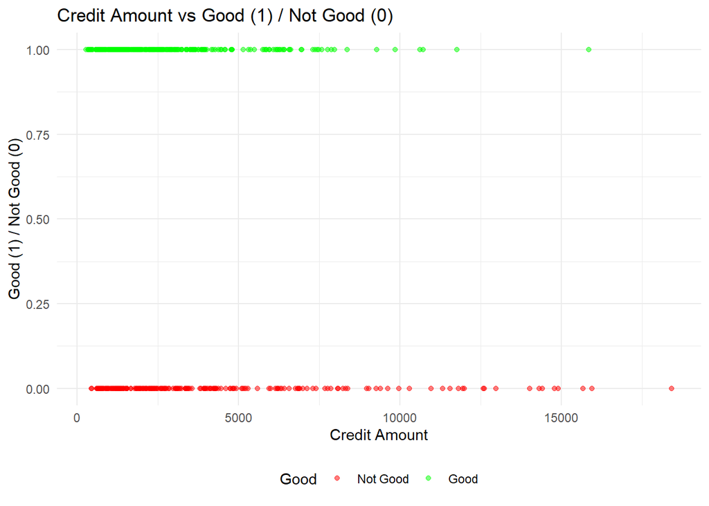

```r
# Gráfico de dispersión para Credit.amount vs Good
ggplot(datos, aes(x = Credit.amount, y = as.numeric(Good) - 1, color = Good)) +
  geom_point(alpha = 0.5) +
  labs(title = "Credit Amount vs Good (1) / Not Good (0)", x = "Credit Amount", y = "Good (1) / Not Good (0)") +
  scale_color_manual(values = c("red", "green")) +
  theme_minimal() +
  theme(legend.position = "bottom")
```

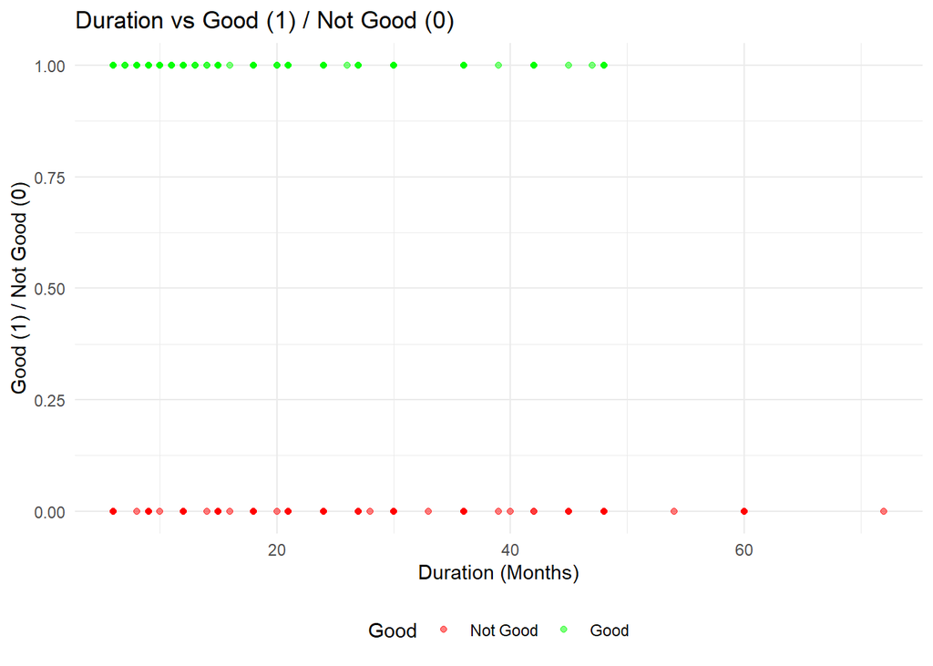

```r
# Gráfico de dispersión para Duration vs Good
ggplot(datos, aes(x = Duration, y = as.numeric(Good) - 1, color = Good)) +
  geom_point(alpha = 0.5) +
  labs(title = "Duration vs Good (1) / Not Good (0)", x = "Duration (Months)", y = "Good (1) / Not Good (0)") +
  scale_color_manual(values = c("red", "green")) +
  theme_minimal() +
  theme(legend.position = "bottom")
```